# Simulations and models of stochastic differential equations

A.C. Guidoum and K. Boukhetala

2017-03-25

# snssde1d()

Assume that we want to describe the following SDE:

Ito form[^1]:

$$\begin{equation}\label{eq:05}
dX_{t} = \frac{1}{2}\theta^{2} X_{t} dt + \theta X_{t} dW_{t},\qquad X_{0}=x_{0} > 0
\end{equation}$$
Stratonovich form:
$$\begin{equation}\label{eq:06}
dX_{t} = \frac{1}{2}\theta^{2} X_{t} dt +\theta X_{t} \circ dW_{t},\qquad X_{0}=x_{0} > 0
\end{equation}$$

In the above $f(t,x)=\frac{1}{2}\theta^{2} x$ and $g(t,x)= \theta x$ ($\theta > 0$), $W_{t}$ is a standard Wiener process. To simulate this models using `snssde1d()` function we need to specify:

- The `drift` and `diffusion` coefficients as R expressions that depend on the state variable `x` and time variable `t`.
- The number of simulation steps `N=1000` (by default: `N=1000`).
- The number of the solution trajectories to be simulated by `M=500` (by default: `M=1`).
- The initial conditions `t0=0`, `x0=10` and end time `T=1` (by default: `t0=0`, `x0=0` and `T=1`).
- The integration step size `Dt=0.001` (by default: `Dt=(T-t0)/N`).
- The choice of process types by the argument `type="ito"` for Ito or `type="str"` for Stratonovich (by default `type="ito"`).
- The numerical method to be used by `method` (by default `method="euler"`).

```r
theta = 0.5
f <- expression( (0.5*theta^2*x) )
g <- expression( theta*x )
mod1 <- snssde1d(drift=f,diffusion=g,x0=10,M=500,type="ito") # Using Ito
mod2 <- snssde1d(drift=f,diffusion=g,x0=10,M=500,type="str") # Using Stratonovich
mod1
```

```
## Ito Sde 1D:
##  | dX(t) = (0.5 * theta^2 * X(t)) * dt + theta * X(t) * dW(t)
## Method:
##  | Euler scheme of order 0.5
## Summary:
##  | Size of process   | N  = 1001.
##  | Number of simulation  | M  = 500.
##  | Initial value     | x0 = 10.
##  | Time of process   | t in [0,1].
##  | Discretization    | Dt = 0.001.
```

```r
mod2
```

```
## Stratonovich Sde 1D:
##  | dX(t) = (0.5 * theta^2 * X(t)) * dt + theta * X(t) o dW(t)
## Method:
##  | Euler scheme of order 0.5
## Summary:
##  | Size of process   | N  = 1001.
##  | Number of simulation  | M  = 500.
##  | Initial value     | x0 = 10.
##  | Time of process   | t in [0,1].
##  | Discretization    | Dt = 0.001.
```

Using Monte-Carlo simulations, the following statistical measures (`S3 method`) for class `snssde1d()` can be approximated for the $X_{t}$ process at any time $t$:

- The expected value $\text{E}(X_{t})$ at time $t$, using the command `mean`.
- The variance $\text{Var}(X_{t})$ at time $t$.
- The median $\text{Med}(X_{t})$ at time $t$, using the command `median`.
- The quartile of $X_{t}$ at time $t$, using the command `quantile`.
- The skewness and the kurtosis of $X_{t}$ at time $t$, using the command `skewness` and `kurtosis`.
- The central moments up to order $p$ of $X_{t}$ at time $t$, using the command `moment`.
- The empirical $\alpha \%$ confidence interval of $X_{t}$ at time $t$ (from the $2.5th$ to the $97.5th$ percentile), using the command `bconfint`.

The summary of the results of `mod1` and `mod2` at time $t=1$ of class `snssde1d()` is given by:

```r
summary(mod1, at = 1)
```

```
##
##  Monte-Carlo Statistics for X(t) at time t = 1
##
## Mean                   11.04319
## Variance               34.51348
## Median                  9.67614
## First quartile          6.88003
## Third quartile         13.35324
## Skewness                1.41619
## Kurtosis                5.60120
## Moment of order 3     287.14814
## Moment of order 4    6672.03563
## Moment of order 5  125490.75202
## Int.conf Inf (95%)      3.62732
## Int.conf Sup (95%)     25.94828
```

```r
summary(mod2, at = 1)
```

```
##
##  Monte-Carlo Statistics for X(t) at time t = 1
##
## Mean                    9.61779
## Variance               28.14247
## Median                  8.48501
## First quartile          6.11644
## Third quartile         12.16451
## Skewness                2.61720
## Kurtosis               19.52529
## Moment of order 3     390.73323
## Moment of order 4   15464.00809
## Moment of order 5  668137.79437
## Int.conf Inf (95%)      2.98779
## Int.conf Sup (95%)     20.63778
```

Hence we can just make use of the `rsde1d()` function to build our random number generator for the conditional density of the $X_{t}|X_{0}$ ($X_{t}^{\text{mod1}}| X_{0}$ and $X_{t}^{\text{mod2}}|X_{0}$) at time $t = 1$.

```r
x1 <- rsde1d(object = mod1, at = 1)  # X(t=1) | X(0)=x0 (Itô SDE)
x2 <- rsde1d(object = mod2, at = 1)  # X(t=1) | X(0)=x0 (Stratonovich SDE)
summary(data.frame(x1,x2))
```

```
##        x1               x2
##  Min.   : 2.204   Min.   : 1.500
##  1st Qu.: 6.880   1st Qu.: 6.116
##  Median : 9.676   Median : 8.485
##  Mean   :11.043   Mean   : 9.618
##  3rd Qu.:13.353   3rd Qu.:12.165
##  Max.   :38.898   Max.   :59.373
```

The function `dsde1d()` can be used to show the kernel density estimation for $X_{t}|X_{0}$ at time $t=1$ with log-normal curves:

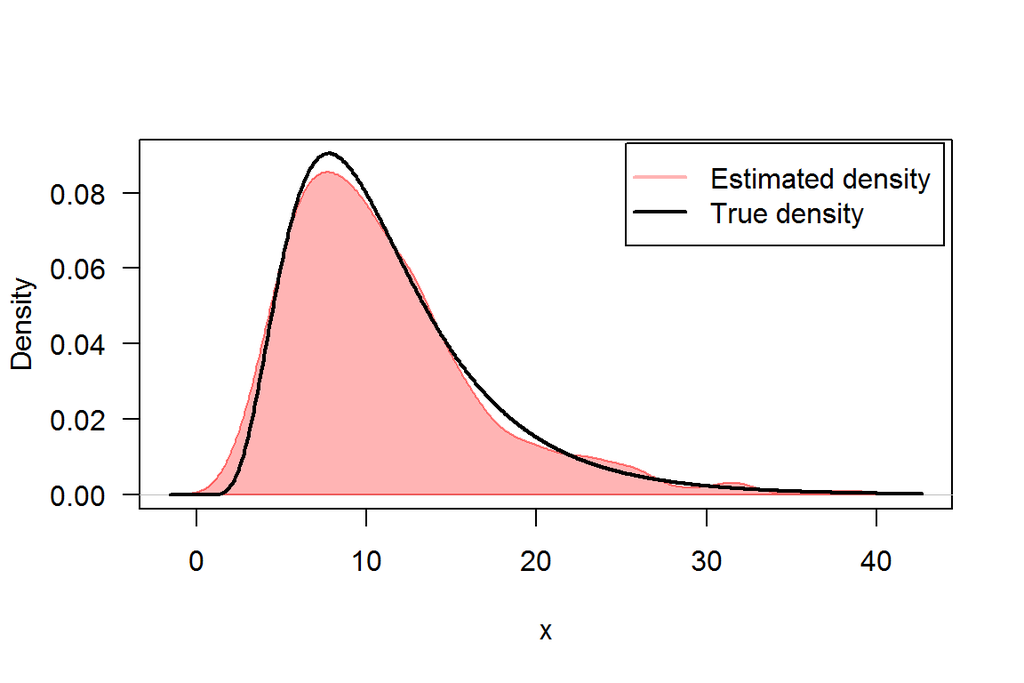

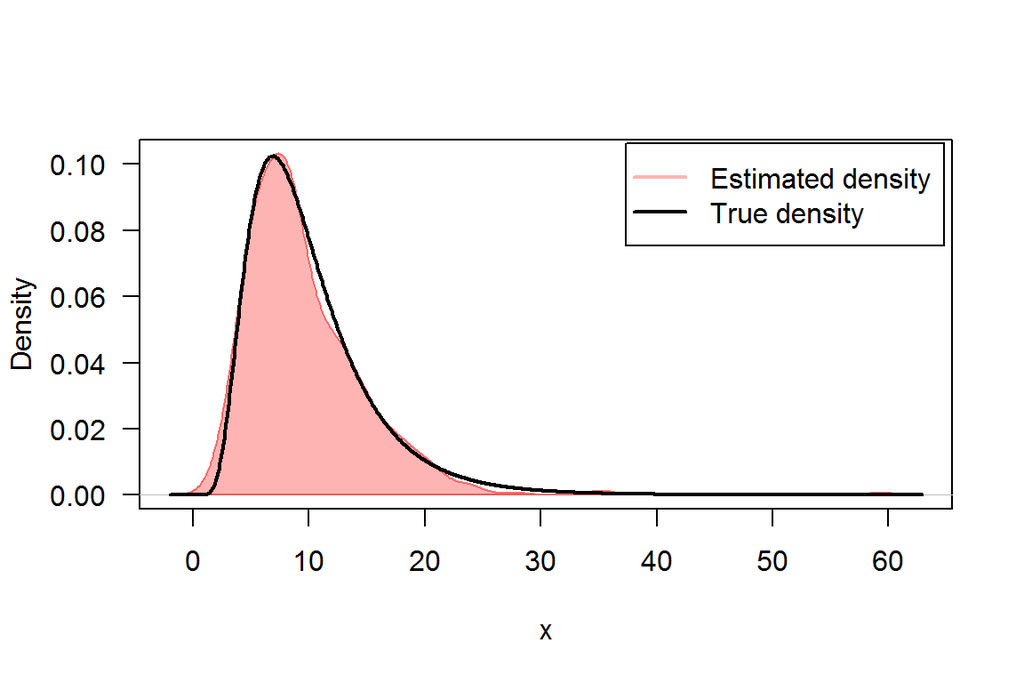

```r
mu1 = log(10); sigma1= sqrt(theta^2)  # log mean and log variance for mod1
mu2 = log(10)-0.5*theta^2 ; sigma2 = sqrt(theta^2) # log mean and log variance for mod2
AppdensI <- dsde1d(mod1, at = 1)
AppdensS <- dsde1d(mod2, at = 1)
plot(AppdensI , dens = function(x) dlnorm(x,meanlog=mu1,sdlog = sigma1))
plot(AppdensS , dens = function(x) dlnorm(x,meanlog=mu2,sdlog = sigma2))
```

In Figure 2, we present the flow of trajectories, the mean path (red lines) of solution of and , with their empirical $95\%$ confidence bands, that is to say from the $2.5th$ to the $97.5th$ percentile for each observation at time $t$ (blue lines):

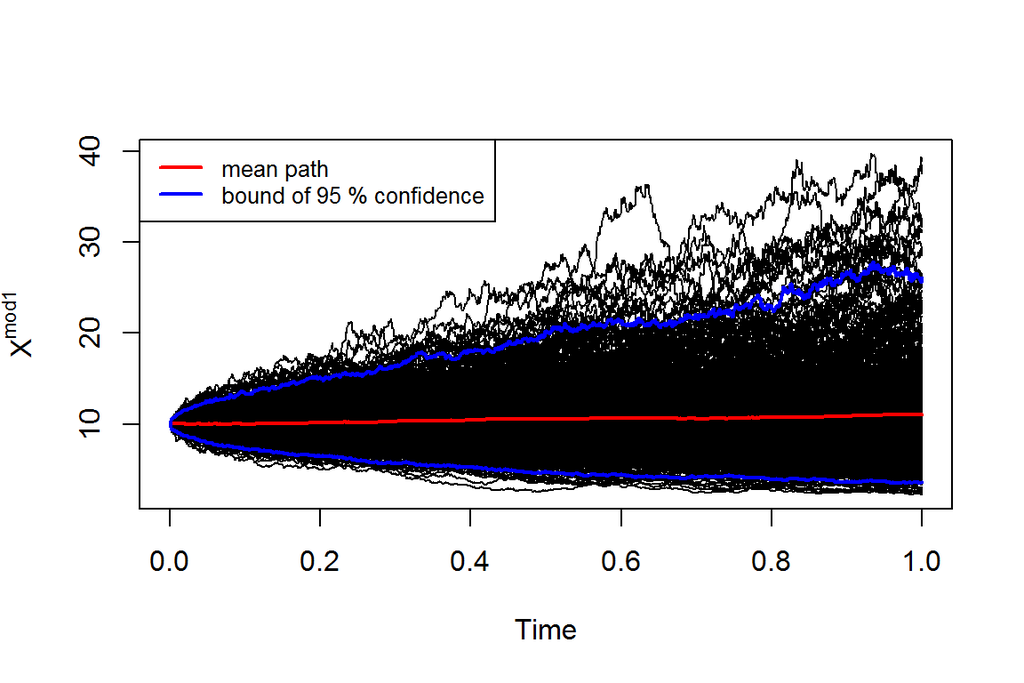

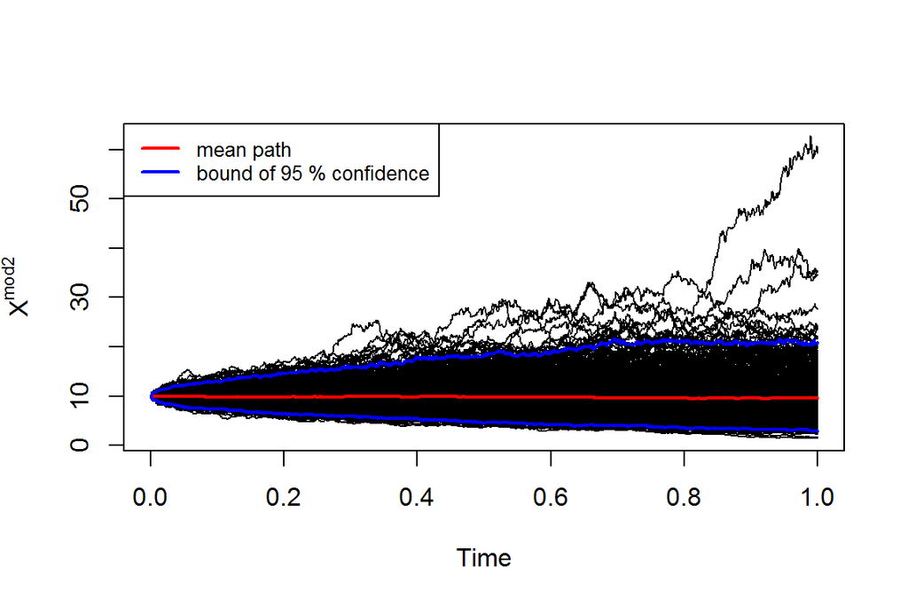

```r
plot(mod1,plot.type="single",ylab=expression(X^mod1))
lines(time(mod1),mean(mod1),col=2,lwd=2)
lines(time(mod1),bconfint(mod1,level=0.95)[,1],col=4,lwd=2)
lines(time(mod1),bconfint(mod1,level=0.95)[,2],col=4,lwd=2)
legend("topleft",c("mean path",paste("bound of",95,"% confidence")),col=c(2,4),lwd=2,cex=0.8)
plot(mod2,plot.type="single",ylab=expression(X^mod2))
lines(time(mod2),mean(mod2),col=2,lwd=2)
lines(time(mod2),bconfint(mod2,level=0.95)[,1],col=4,lwd=2)
lines(time(mod2),bconfint(mod2,level=0.95)[,2],col=4,lwd=2)
legend("topleft",c("mean path",paste("bound of",95,"% confidence")),col=c(2,4),lwd=2,cex=0.8)
```

Return to snssde1d()

# snssde2d()

The following $2$-dimensional SDE’s with a vector of drift and a diagonal matrix of diffusion coefficients:

Ito form:
$$\begin{equation}\label{eq:09}
\begin{cases}
dX_t = f_{x}(t,X_{t},Y_{t}) dt + g_{x}(t,X_{t},Y_{t}) dW_{1,t}\\
dY_t = f_{y}(t,X_{t},Y_{t}) dt + g_{y}(t,X_{t},Y_{t}) dW_{2,t}
\end{cases}
\end{equation}$$
Stratonovich form:
$$\begin{equation}\label{eq:10}
\begin{cases}
dX_t = f_{x}(t,X_{t},Y_{t}) dt + g_{x}(t,X_{t},Y_{t}) \circ dW_{1,t}\\
dY_t = f_{y}(t,X_{t},Y_{t}) dt + g_{y}(t,X_{t},Y_{t}) \circ dW_{2,t}
\end{cases}
\end{equation}$$

$W_{1,t}$ and $W_{2,t}$ is a two independent standard Wiener process. To simulate $2d$ models using `snssde2d()` function we need to specify:

- The `drift` (2d) and `diffusion` (2d) coefficients as R expressions that depend on the state variable `x`, `y` and time variable `t`.
- The number of simulation steps `N` (default: `N=1000`).
- The number of the solution trajectories to be simulated by `M` (default: `M=1`).
- The initial conditions `t0`, `x0` and end time `T` (default: `t0=0`, `x0=c(0,0)` and `T=1`).
- The integration step size `Dt` (default: `Dt=(T-t0)/N`).
- The choice of process types by the argument `type="ito"` for Ito or `type="str"` for Stratonovich (default `type="ito"`).
- The numerical method to be used by `method` (default `method="euler"`).

## Ornstein-Uhlenbeck process and its integral

The Ornstein-Uhlenbeck (OU) process has a long history in physics. Introduced in essence by Langevin in his famous 1908 paper on Brownian motion, the process received a more thorough mathematical examination several decades later by Uhlenbeck and Ornstein (1930). The OU process is understood here to be the univariate continuous Markov process $X_t$. In mathematical terms, the equation is written as an Ito equation:
$$\begin{equation}\label{eq016}
dX_t = -\frac{1}{\mu} X_t dt + \sqrt{\sigma} dW_t,\quad X_{0}=x_{0}
\end{equation}$$
In these equations, $\mu$ and $\sigma$ are positive constants called, respectively, the relaxation time and the diffusion constant. The time integral of the OU process $X_t$ (or indeed of any process $X_t$) is defined to be the process $Y_t$ that satisfies:
$$\begin{equation}\label{eq017}
Y_{t} = Y_{0}+\int X_{t} dt \Leftrightarrow dY_t = X_{t} dt ,\quad Y_{0}=y_{0}
\end{equation}$$
$Y_t$ is not itself a Markov process; however, $X_t$ and $Y_t$ together comprise a bivariate continuous Markov process. We wish to find the solutions $X_t$ and $Y_t$ to the coupled time-evolution equations:
$$\begin{equation}\label{eq018}
\begin{cases}
dX_t = -\frac{1}{\mu} X_t dt + \sqrt{\sigma} dW_t\\
dY_t = X_{t} dt
\end{cases}
\end{equation}$$

We simulate a flow of $500$ trajectories of $(X_{t},Y_{t})$, with integration step size $\Delta t = 0.01$, and using second Milstein method.

```r
x=5;y=0
mu=3;sigma=0.5
fx <- expression(-(x/mu),x)
gx <- expression(sqrt(sigma),0)
mod2d <- snssde2d(drift=fx,diffusion=gx,Dt=0.01,M=500,x0=c(x,y),method="smilstein")
mod2d
```

```
## Ito Sde 2D:
##  | dX(t) = -(X(t)/mu) * dt + sqrt(sigma) * dW1(t)
##  | dY(t) = X(t) * dt + 0 * dW2(t)
## Method:
##  | Second Milstein scheme of order 1.5
## Summary:
##  | Size of process   | N  = 1001.
##  | Number of simulation  | M  = 500.
##  | Initial values    | (x0,y0) = (5,0).
##  | Time of process   | t in [0,10].
##  | Discretization    | Dt = 0.01.
```

```r
summary(mod2d)
```

```
##
##  Monte-Carlo Statistics for (X(t),Y(t)) at time t = 10
##                           X          Y
## Mean                0.16435   14.47619
## Variance            0.82224   24.76162
## Median              0.12762   14.46409
## First quartile     -0.50351   10.83284
## Third quartile      0.76750   17.93925
## Skewness            0.18123    0.02360
## Kurtosis            2.89768    2.58953
## Moment of order 3   0.13512    2.90818
## Moment of order 4   1.95904 1587.73848
## Moment of order 5   0.79038  108.72301
## Int.conf Inf (95%) -1.46128    4.66876
## Int.conf Sup (95%)  2.06418   24.03663
```

For plotting (back in time) using the command `plot`, the results of the simulation are shown in Figure 3.

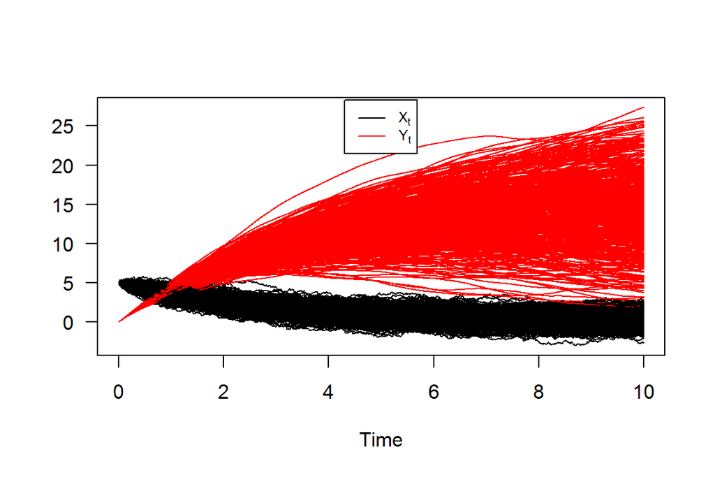

```r
plot(mod2d)
```

Take note of the well known result, which can be derived from either this equations. That for any $t > 0$ the OU process $X_t$ and its integral $Y_t$ will be the normal distribution with mean and variance given by:
$$\begin{cases}
\text{E}(X_{t}) =x_{0} e^{-t/\mu} &\text{and}\quad\text{Var}(X_{t})=\frac{\sigma \mu}{2} \left (1-e^{-2t/\mu}\right )\\
\text{E}(Y_{t}) = y_{0}+x_{0}\mu \left (1-e^{-t/\mu}\right ) &\text{and}\quad\text{Var}(Y_{t})=\sigma\mu^{3}\left (\frac{t}{\mu}-2\left (1-e^{-t/\mu}\right )+\frac{1}{2}\left (1-e^{-2t/\mu}\right )\right )
\end{cases}$$

Hence we can just make use of the `rsde2d()` function to build our random number for $(X_{t},Y_{t})$ at time $t = 10$.

```r
out <- rsde2d(object = mod2d, at = 10)
summary(out)
```

```
##        x                 y
##  Min.   :-2.6374   Min.   : 1.749
##  1st Qu.:-0.5035   1st Qu.:10.833
##  Median : 0.1276   Median :14.464
##  Mean   : 0.1643   Mean   :14.476
##  3rd Qu.: 0.7675   3rd Qu.:17.939
##  Max.   : 3.1062   Max.   :27.377
```

For each SDE type and for each numerical scheme, the density of $X_t$ and $Y_t$ at time $t=10$ are reported using `dsde2d()` function, see e.g. Figure 4: the marginal density of $X_t$ and $Y_t$ at time $t=10$.

```r
denM <- dsde2d(mod2d,pdf="M",at =10)
denM
```

```
##
##  Marginal density of X(t)|X(0)=x0 at time t = 10
##
## Data: x (500 obs.);  Bandwidth 'bw' = 0.2355
##
##        x                  f(x)
##  Min.   :-3.343802   Min.   :0.0000383
##  1st Qu.:-1.554705   1st Qu.:0.0059189
##  Median : 0.234393   Median :0.0645287
##  Mean   : 0.234393   Mean   :0.1395981
##  3rd Qu.: 2.023491   3rd Qu.:0.2782026
##  Max.   : 3.812589   Max.   :0.4003288
##
##  Marginal density of Y(t)|Y(0)=y0 at time t = 10
##
## Data: y (500 obs.);  Bandwidth 'bw' = 1.292
##
##        y                  f(y)
##  Min.   :-2.127983   Min.   :0.00000732
##  1st Qu.: 6.217316   1st Qu.:0.00361625
##  Median :14.562615   Median :0.02345091
##  Mean   :14.562615   Mean   :0.02992753
##  3rd Qu.:22.907915   3rd Qu.:0.05506848
##  Max.   :31.253214   Max.   :0.07816690
```

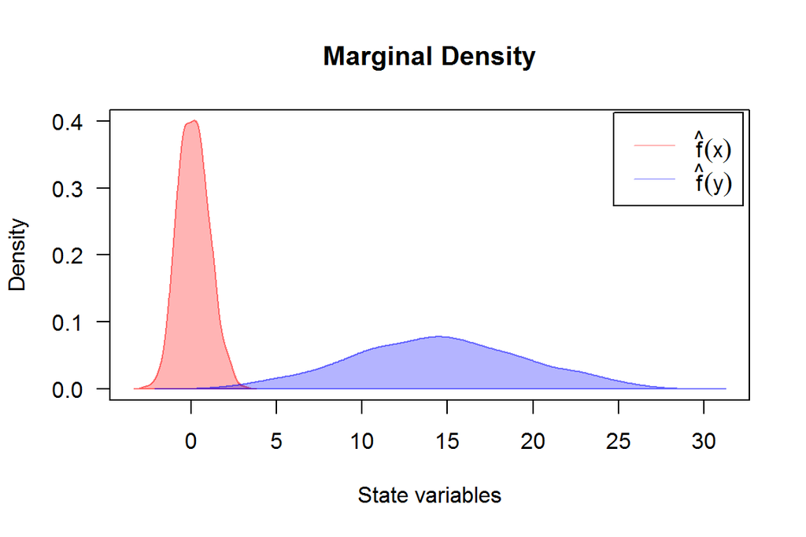

```r
plot(denM, main="Marginal Density")
```

Created using `dsde2d()` plotted in (x, y)-space with `dim = 2`. A `contour` and `image` plot of density obtained from a realization of system $(X_{t},Y_{t})$ at time `t=10`.

```r
denJ <- dsde2d(mod2d,pdf="J",at =10)
denJ
```

```
##
##  Joint density of (X(t),Y(t)|X(0)=x0,Y(0)=y0) at time t = 10
##
## Data: (x,y) (2 x 500 obs.);
##
##        x                    y                 f(x,y)
##  Min.   :-2.6373740   Min.   : 1.748691   Min.   :0.00000000
##  1st Qu.:-1.2014904   1st Qu.: 8.155653   1st Qu.:0.00030789
##  Median : 0.2343932   Median :14.562615   Median :0.00267498
##  Mean   : 0.2343932   Mean   :14.562615   Mean   :0.00660300
##  3rd Qu.: 1.6702768   3rd Qu.:20.969578   3rd Qu.:0.00991682
##  Max.   : 3.1061604   Max.   :27.376540   Max.   :0.03481699
```

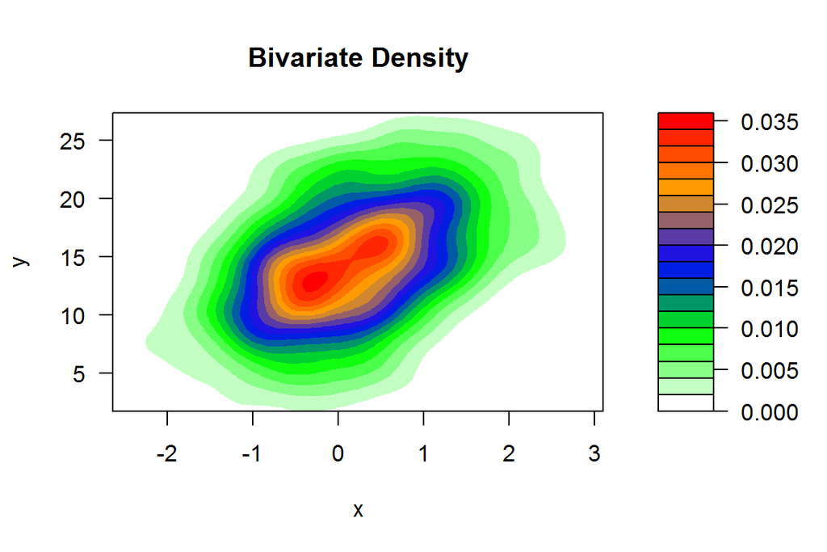

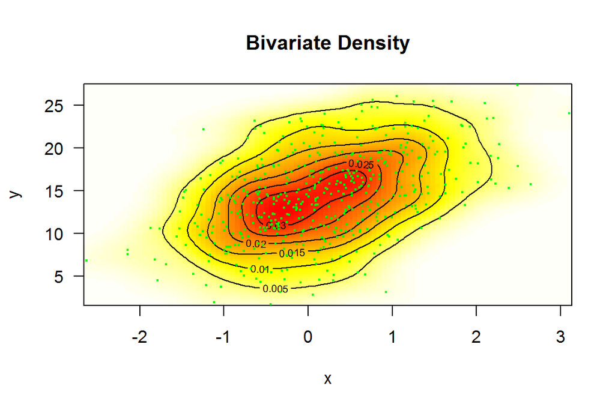

```r
plot(denJ,display="contour",main="Bivariate Density")
plot(denJ,display="image",drawpoints=TRUE,col.pt="green",cex=0.25,pch=19,main="Bivariate Density")
```

A $3$D plot of the density obtained with:

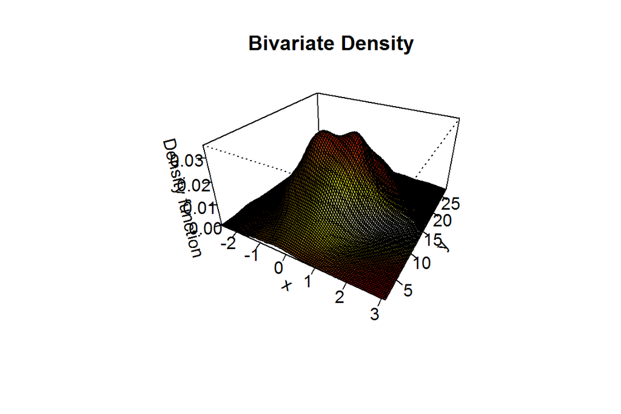

```r
plot(denJ,main="Bivariate Density")
```

Return to snssde2d()

## The stochastic Van-der-Pol equation

The Van der Pol (1922) equation is an ordinary differential equation that can be derived from the Rayleigh differential equation by differentiating and setting $\dot{x}=y$, see Naess and Hegstad (1994); Leung (1995) and for more complex dynamics in Van-der-Pol equation see Jing et al. (2006). It is an equation describing self-sustaining oscillations in which energy is fed into small oscillations and removed from large oscillations. This equation arises in the study of circuits containing vacuum tubes and is given by:
$$\begin{equation}\label{eq:12}
\ddot{X}-\mu (1-X^{2}) \dot{X} + X = 0
\end{equation}$$
where $x$ is the position coordinate (which is a function of the time $t$), and $\mu$ is a scalar parameter indicating the nonlinearity and the strength of the damping, to simulate the deterministic equation see Grayling (2014) for more details. Consider stochastic perturbations of the Van-der-Pol equation, and random excitation force of such systems by White noise $\xi_{t}$, with delta-type correlation function $\text{E}(\xi_{t}\xi_{t+h})=2\sigma \delta (h)$
$$\begin{equation}\label{eq:13}
\ddot{X}-\mu (1-X^{2}) \dot{X} + X = \xi_{t},
\end{equation}$$
where $\mu > 0$ . It’s solution cannot be obtained in terms of elementary functions, even in the phase plane. The White noise $\xi_{t}$ is formally derivative of the Wiener process $W_{t}$. The representation of a system of two first order equations follows the same idea as in the deterministic case by letting $\dot{x}=y$, from physical equation we get the above system:
$$\begin{equation}\label{eq:14}
\begin{cases}
\dot{X} = Y \\
\dot{Y} = \mu \left(1-X^{2}\right) Y - X + \xi_{t}
\end{cases}
\end{equation}$$
The system can mathematically explain by a Stratonovitch equations:
$$\begin{equation}\label{eq:15}
\begin{cases}
dX_{t} = Y_{t} dt \\
dY_{t} = \left(\mu (1-X^{2}_{t}) Y_{t} - X_{t}\right) dt + 2 \sigma \circ dW_{2,t}
\end{cases}
\end{equation}$$

Implemente in R as follows, with integration step size $\Delta t = 0.01$ and using stochastic Runge-Kutta methods 1-stage.

```r
mu = 4; sigma=0.1
fx <- expression( y ,  (mu*( 1-x^2 )* y - x))
gx <- expression( 0 ,2*sigma)
mod2d <- snssde2d(drift=fx,diffusion=gx,N=10000,Dt=0.01,type="str",method="rk1")
mod2d
```

```
## Stratonovich Sde 2D:
##  | dX(t) = Y(t) * dt + 0 o dW1(t)
##  | dY(t) = (mu * (1 - X(t)^2) * Y(t) - X(t)) * dt + 2 * sigma o dW2(t)
## Method:
##  | Runge-Kutta method of order 1
## Summary:
##  | Size of process   | N  = 10001.
##  | Number of simulation  | M  = 1.
##  | Initial values    | (x0,y0) = (0,0).
##  | Time of process   | t in [0,100].
##  | Discretization    | Dt = 0.01.
```

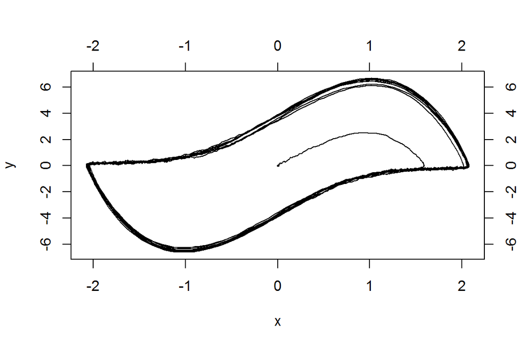

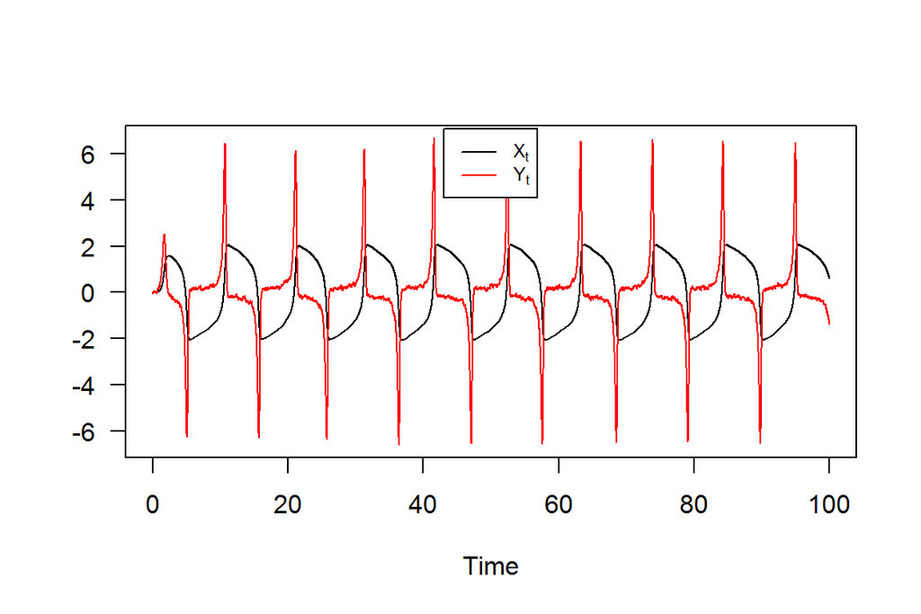

```r
plot2d(mod2d) ## in plane (O,X,Y)
plot(mod2d)   ## back in time
```

Return to snssde2d()

# snssde3d()

The following $3$-dimensional SDE’s with a vector of drift and a diagonal matrix of diffusion coefficients:

Ito form:
$$\begin{equation}\label{eq17}
\begin{cases}
dX_t = f_{x}(t,X_{t},Y_{t},Z_{t}) dt + g_{x}(t,X_{t},Y_{t},Z_{t}) dW_{1,t}\\
dY_t = f_{y}(t,X_{t},Y_{t},Z_{t}) dt + g_{y}(t,X_{t},Y_{t},Z_{t}) dW_{2,t}\\
dZ_t = f_{z}(t,X_{t},Y_{t},Z_{t}) dt + g_{z}(t,X_{t},Y_{t},Z_{t}) dW_{3,t}
\end{cases}
\end{equation}$$
Stratonovich form:
$$\begin{equation}\label{eq18}
\begin{cases}
dX_t = f_{x}(t,X_{t},Y_{t},Z_{t}) dt + g_{x}(t,X_{t},Y_{t},Z_{t}) \circ dW_{1,t}\\
dY_t = f_{y}(t,X_{t},Y_{t},Z_{t}) dt + g_{y}(t,X_{t},Y_{t},Z_{t}) \circ dW_{2,t}\\
dZ_t = f_{z}(t,X_{t},Y_{t},Z_{t}) dt + g_{z}(t,X_{t},Y_{t},Z_{t}) \circ dW_{3,t}
\end{cases}
\end{equation}$$

$W_{1,t}$, $W_{2,t}$ and $W_{3,t}$ is a 3 independent standard Wiener process. To simulate this system using `snssde3d()` function we need to specify:

- The `drift` (3d) and `diffusion` (3d) coefficients as R expressions that depend on the state variables `x`, `y` , `z` and time variable `t`.
- The number of simulation steps `N` (default: `N=1000`).
- The number of the solution trajectories to be simulated by `M` (default: `M=1`).
- The initial conditions `t0`, `x0` and end time `T` (default: `t0=0`, `x0=c(0,0,0)` and `T=1`).
- The integration step size `Dt` (default: `Dt=(T-t0)/N`).
- The choice of process types by the argument `type="ito"` for Ito or `type="str"` for Stratonovich (default `type="ito"`).
- The numerical method to be used by `method` (default `method="euler"`).

## Basic example

Assume that we want to describe the following SDE’s (3D) in Ito form:
$$\begin{equation}\label{eq0166}
\begin{cases}
dX_t = 4 (-1-X_{t}) Y_{t} dt + 0.2 dW_{1,t}\\
dY_t = 4 (1-Y_{t}) X_{t} dt + 0.2 dW_{2,t}\\
dZ_t = 4 (1-Z_{t}) Y_{t} dt + 0.2 dW_{3,t}
\end{cases}
\end{equation}$$

We simulate a flow of 500 trajectories, with integration step size $\Delta t = 0.001$.

```r
fx <- expression(4*(-1-x)*y , 4*(1-y)*x , 4*(1-z)*y)
gx <- rep(expression(0.2),3)
mod3d <- snssde3d(x0=c(x=2,y=-2,z=-2),drift=fx,diffusion=gx,N=1000,M=500)
mod3d
```

```
## Ito Sde 3D:
##  | dX(t) = 4 * (-1 - X(t)) * Y(t) * dt + 0.2 * dW1(t)
##  | dY(t) = 4 * (1 - Y(t)) * X(t) * dt + 0.2 * dW2(t)
##  | dZ(t) = 4 * (1 - Z(t)) * Y(t) * dt + 0.2 * dW3(t)
## Method:
##  | Euler scheme of order 0.5
## Summary:
##  | Size of process   | N  = 1001.
##  | Number of simulation  | M  = 500.
##  | Initial values    | (x0,y0,z0) = (2,-2,-2).
##  | Time of process   | t in [0,1].
##  | Discretization    | Dt = 0.001.
```

```r
summary(mod3d)
```

```
##
##   Monte-Carlo Statistics for (X(t),Y(t),Z(t)) at time t = 1
##                           X       Y        Z
## Mean               -0.79248 0.86862  0.79436
## Variance            0.00870 0.09680  0.00967
## Median             -0.79519 0.81592  0.80148
## First quartile     -0.86393 0.63552  0.72762
## Third quartile     -0.73416 1.05511  0.86827
## Skewness            0.33787 0.58001 -0.22169
## Kurtosis            3.19287 2.96294  2.77273
## Moment of order 3   0.00027 0.01747 -0.00021
## Moment of order 4   0.00024 0.02776  0.00026
## Moment of order 5   0.00003 0.01234 -0.00002
## Int.conf Inf (95%) -0.95983 0.38219  0.59257
## Int.conf Sup (95%) -0.59059 1.58563  0.97425
```

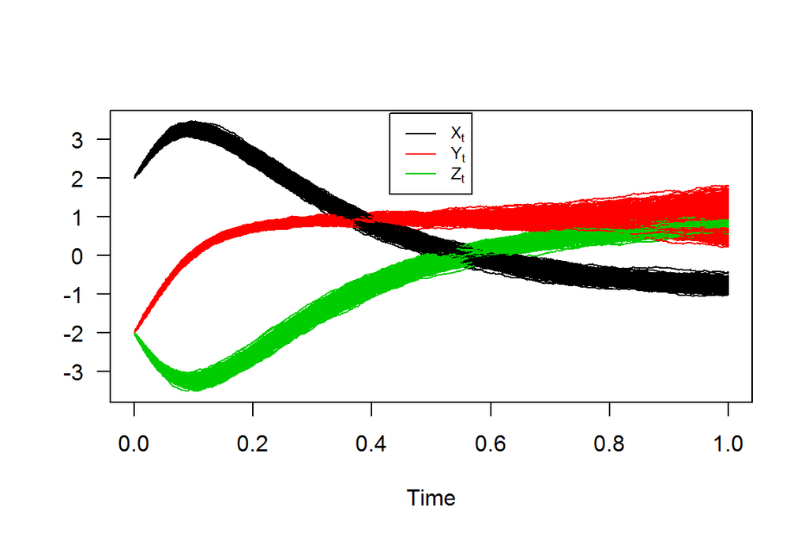

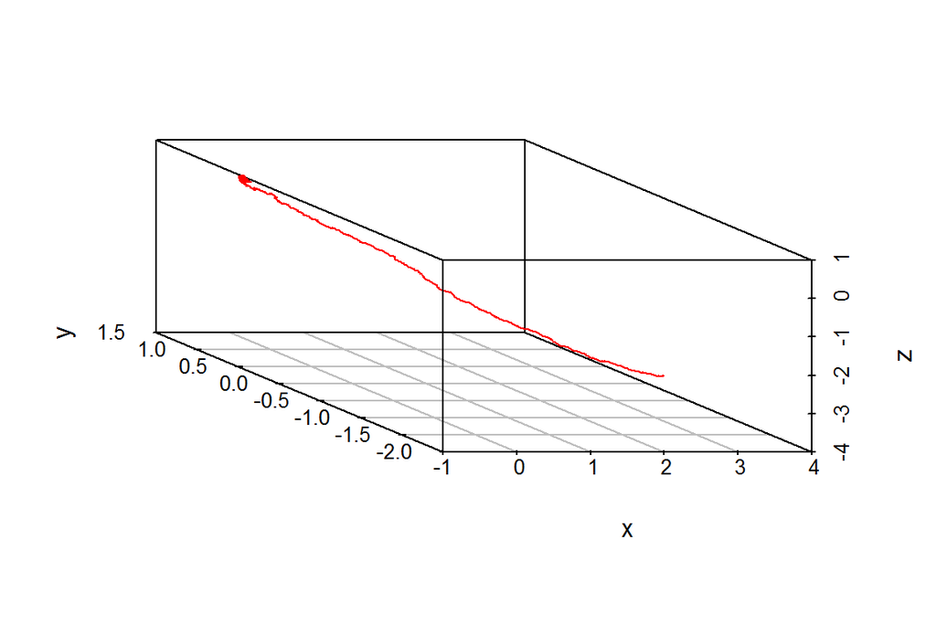

```r
plot(mod3d,union = TRUE)         ## back in time
plot3D(mod3d,display="persp")    ## in space (O,X,Y,Z)
```

For each SDE type and for each numerical scheme, the marginal density of $X_t$, $Y_t$ and $Z_t$ at time $t=1$ are reported using `dsde3d()` function, see e.g. Figure 8.

```r
den <- dsde3d(mod3d,pdf="M",at =1)
den
```

```
##
##  Marginal density for X(t)|X(0)=x0 at time t = 1
##
## Data: x (500 obs.);  Bandwidth 'bw' = 0.02422
##
##        x                   f(x)
##  Min.   :-1.0999820   Min.   :0.000374
##  1st Qu.:-0.9165744   1st Qu.:0.049528
##  Median :-0.7331667   Median :0.581942
##  Mean   :-0.7331667   Mean   :1.361743
##  3rd Qu.:-0.5497591   3rd Qu.:2.762533
##  Max.   :-0.3663515   Max.   :4.147440
##
##  Marginal density for Y(t)|Y(0)=y0 at time t = 1
##
## Data: y (500 obs.);  Bandwidth 'bw' = 0.08079
##
##        y                   f(y)
##  Min.   :-0.0270619   Min.   :0.0001683
##  1st Qu.: 0.4918822   1st Qu.:0.0685150
##  Median : 1.0108264   Median :0.3049756
##  Mean   : 1.0108264   Mean   :0.4812734
##  3rd Qu.: 1.5297705   3rd Qu.:0.9105846
##  Max.   : 2.0487147   Max.   :1.3148288
##
##  Marginal density for Z(t)|Z(0)=z0 at time t = 1
##
## Data: z (500 obs.);  Bandwidth 'bw' = 0.02553
##
##        z                  f(z)
##  Min.   :0.4249639   Min.   :0.000355
##  1st Qu.:0.6016392   1st Qu.:0.135101
##  Median :0.7783146   Median :0.799373
##  Mean   :0.7783146   Mean   :1.413634
##  3rd Qu.:0.9549899   3rd Qu.:2.807504
##  Max.   :1.1316652   Max.   :3.909531
```

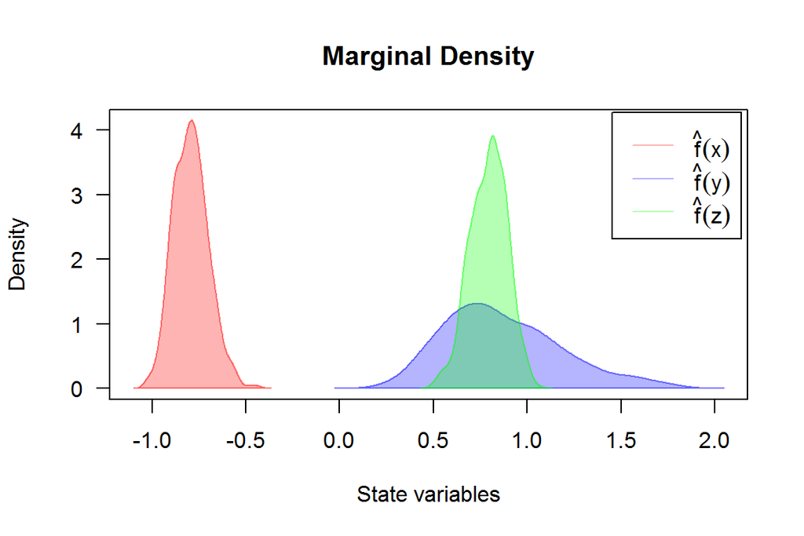

```r
plot(den, main="Marginal Density")
```

For Joint density for $(X_t,Y_t,Z_t)$ (for more details, see package sm or ks.)

```r
denJ <- dsde3d(mod3d,pdf="J")
denJ
plot(denJ,display="persp")
mtext("Contour surface of kernel density estimate")
```

[output not shown]

Return to snssde3d()

## Attractive model for 3D diffusion processes

If we assume that $U_w( x , y , z , t )$, $V_w( x , y , z , t )$ and $S_w( x , y , z , t )$ are neglected and the dispersion coefficient $D( x , y , z )$ is constant. A system becomes (see Boukhetala,1996):
$$\begin{eqnarray}\label{eq19}
% \nonumber to remove numbering (before each equation)
\begin{cases}
dX_t = \left(\frac{-K X_{t}}{\sqrt{X^{2}_{t} + Y^{2}_{t} + Z^{2}_{t}}}\right) dt + \sigma dW_{1,t} \nonumber\\
dY_t = \left(\frac{-K Y_{t}}{\sqrt{X^{2}_{t} + Y^{2}_{t} + Z^{2}_{t}}}\right) dt + \sigma dW_{2,t} \\
dZ_t = \left(\frac{-K Z_{t}}{\sqrt{X^{2}_{t} + Y^{2}_{t} + Z^{2}_{t}}}\right) dt + \sigma dW_{3,t} \nonumber
\end{cases}
\end{eqnarray}$$

with initial conditions $(X_{0},Y_{0},Z_{0})=(1,1,1)$, by specifying the drift and diffusion coefficients of three processes $X_{t}$, $Y_{t}$ and $Z_{t}$ as R expressions which depends on the three state variables `(x,y,z)` and time variable `t`, with integration step size `Dt=0.0001`.

```r
K = 4; s = 1; sigma = 0.2
fx <- expression( (-K*x/sqrt(x^2+y^2+z^2)) , (-K*y/sqrt(x^2+y^2+z^2)) , (-K*z/sqrt(x^2+y^2+z^2)) )
gx <- rep(expression(sigma),3)
mod3d <- snssde3d(drift=fx,diffusion=gx,N=10000,x0=c(x=1,y=1,z=1))
mod3d
```

```
## Ito Sde 3D:
##  | dX(t) = (-K * X(t)/sqrt(X(t)^2 + Y(t)^2 + Z(t)^2)) * dt + sigma * dW1(t)
##  | dY(t) = (-K * Y(t)/sqrt(X(t)^2 + Y(t)^2 + Z(t)^2)) * dt + sigma * dW2(t)
##  | dZ(t) = (-K * Z(t)/sqrt(X(t)^2 + Y(t)^2 + Z(t)^2)) * dt + sigma * dW3(t)
## Method:
##  | Euler scheme of order 0.5
## Summary:
##  | Size of process   | N  = 10001.
##  | Number of simulation  | M  = 1.
##  | Initial values    | (x0,y0,z0) = (1,1,1).
##  | Time of process   | t in [0,1].
##  | Discretization    | Dt = 1e-04.
```

The results of simulation are shown:

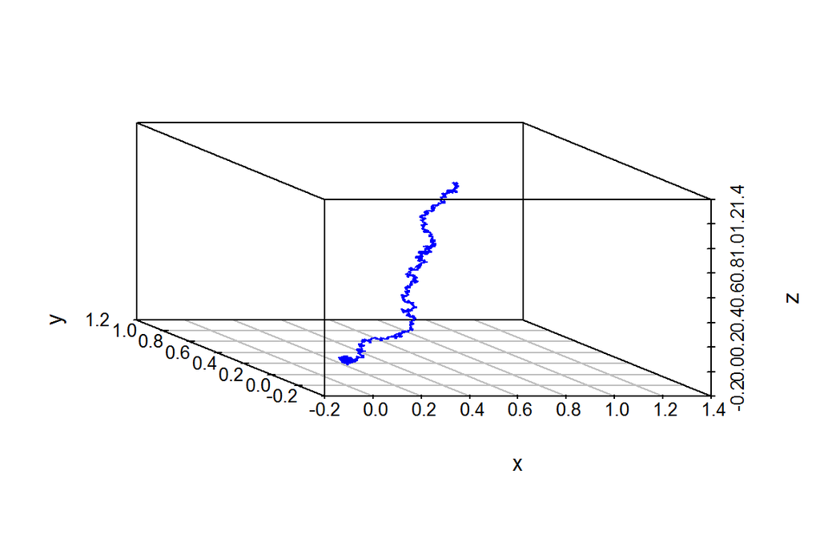

```r
plot3D(mod3d,display="persp",col="blue")
```

Return to snssde3d()

## Transformation of an SDE one-dimensional

Next is an example of one-dimensional SDE driven by three independent Brownian motions ($W_{1,t}$,$W_{2,t}$,$W_{3,t}$), as follows:
$$\begin{equation}\label{eq20}
dX_{t} = \mu W_{1,t} dt + \sigma W_{2,t} dW_{3,t}
\end{equation}$$
To simulate the solution of the process $X_t$, we make a transformation to a system of three equations as follows:
$$\begin{eqnarray}\label{eq21}
\begin{cases}
% \nonumber to remove numbering (before each equation)
dX_t = \mu Y_{t} dt + \sigma Z_{t} dW_{3,t} \nonumber\\
dY_t = dW_{1,t} \\
dZ_t = dW_{2,t} \nonumber
\end{cases}
\end{eqnarray}$$

run by calling the function `snssde3d()` to produce a simulation of the solution, with $\mu = 1$ and $\sigma = 1$.

```r
fx <- expression(y,0,0)
gx <- expression(z,1,1)
modtra <- snssde3d(drift=fx,diffusion=gx,M=500)
modtra
```

```
## Ito Sde 3D:
##  | dX(t) = Y(t) * dt + Z(t) * dW1(t)
##  | dY(t) = 0 * dt + 1 * dW2(t)
##  | dZ(t) = 0 * dt + 1 * dW3(t)
## Method:
##  | Euler scheme of order 0.5
## Summary:
##  | Size of process   | N  = 1001.
##  | Number of simulation  | M  = 500.
##  | Initial values    | (x0,y0,z0) = (0,0,0).
##  | Time of process   | t in [0,1].
##  | Discretization    | Dt = 0.001.
```

```r
summary(modtra)
```

```
##
##   Monte-Carlo Statistics for (X(t),Y(t),Z(t)) at time t = 1
##                           X        Y        Z
## Mean               -0.00637  0.01584  0.01956
## Variance            0.82162  1.06164  0.98480
## Median              0.03692  0.08289  0.05760
## First quartile     -0.54098 -0.66921 -0.60428
## Third quartile      0.56493  0.67993  0.64193
## Skewness           -0.35442 -0.22477 -0.10933
## Kurtosis            4.02014  3.02166  3.15964
## Moment of order 3  -0.26395 -0.24587 -0.10684
## Moment of order 4   2.71381  3.40564  3.06433
## Moment of order 5  -3.13266 -2.24807 -1.09098
## Int.conf Inf (95%) -1.96767 -2.10310 -2.06506
## Int.conf Sup (95%)  1.72106  1.94134  2.03285
```

the following code produces the result in Figure 9.

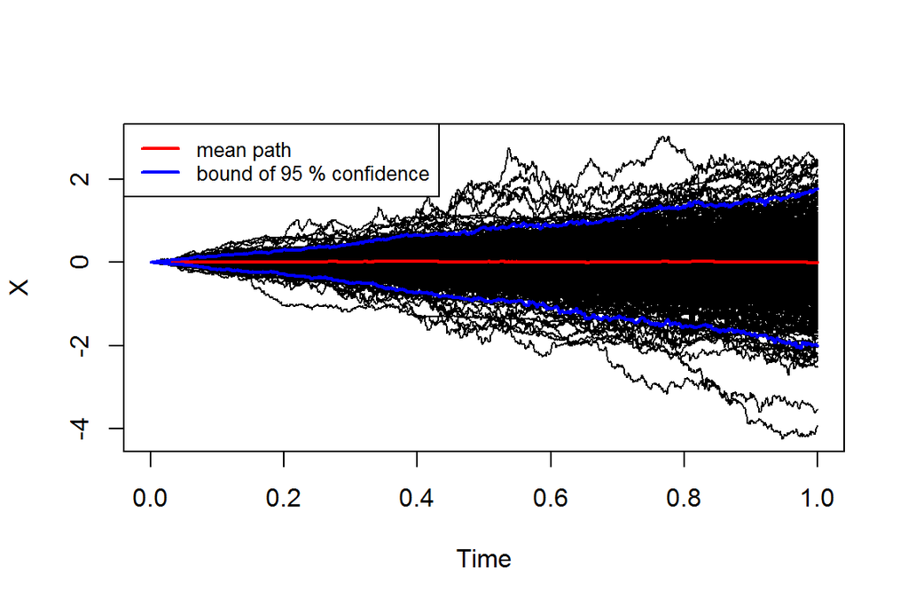

```r
plot(modtra$X,plot.type="single",ylab="X")
lines(time(modtra),mean(modtra)$X,col=2,lwd=2)
lines(time(modtra),bconfint(modtra,level=0.95)$X[,1],col=4,lwd=2)
lines(time(modtra),bconfint(modtra,level=0.95)$X[,2],col=4,lwd=2)
legend("topleft",c("mean path",paste("bound of",95,"% confidence")),col=c(2,4),lwd=2,cex=0.8)
```

```r
den <- dsde3d(modtra,at=1)
den$resx
```

[output not shown]

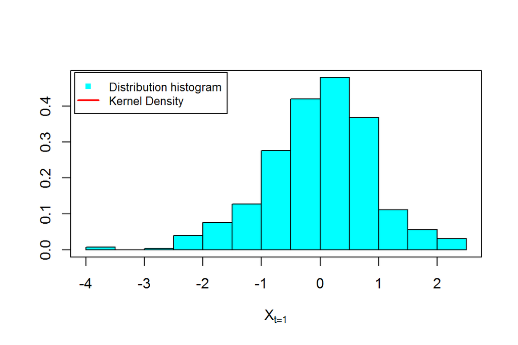

```r
MASS::truehist(den$ech$x,xlab = expression(X[t==1]));box()
lines(den$resx,col="red",lwd=2)
legend("topleft",c("Distribution histogram","Kernel Density"),inset =.01,pch=c(15,NA),lty=c(NA,1),col=c("cyan","red"),lwd=2,cex=0.8)
```

Return to snssde3d()

[^1]: The equivalently of $X_{t}^{\text{mod1}}$ the following Stratonovich SDE: $dX_{t} = \theta X_{t} \circ dW_{t}$.